# picciano-m5

Andrew Picciano

11/21/2019

# 1 Set up and Deliverable

# 2 Matrix Representation

```r
n <- 1000
d <- runif(n*n)

d[d < 0.80] <- NA    # each edge has 20% chance of occuring, so 80% NA
d <- matrix(d, nrow = n, ncol = n)  # shaping vector to n x n matrix
diag(d) <- NA  #no self-loops (can't show with itself)
d[upper.tri(d)] = t(d[upper.tri(d)])   # undirected graphs are symmetric

# matrix(d,ncol = 3, byrow = TRUE )    #example

AdjMatrix2List <- function(d)  {
  weight <- c()
  for (i in 1:nrow(d)) {
      for (j in 1:ncol(d)) {
        if (!is.na(d[i,j]))  {
          weight <-  append(weight, c(i, j, d[i,j])) #3 element vector, which is i,j, weight
        }
      }
    ds <- matrix(c(weight) , ncol = 3, byrow = TRUE)
  }
colnames(ds) <- c("Head", "Tail", "Weight")
return(ds)
}

ds <- AdjMatrix2List(d)
str(ds)
```

```
##  num [1:199889, 1:3] 1 1 1 1 1 1 1 1 1 1 ...
##  - attr(*, "dimnames")=List of 2
##   ..$ : NULL
##   ..$ : chr [1:3] "Head" "Tail" "Weight"
```

# 3 Euclidean Minimum Spanning Tree

### Calling out Part 1 below: The Adjacency Matrix is a complete graph because every segment is connected.

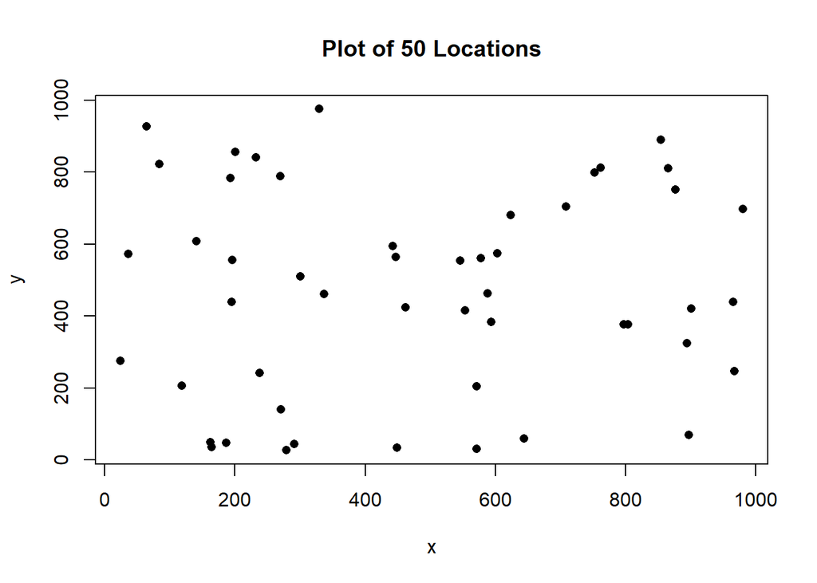

```r
set.seed(31486)

#### Generate 50 random locations 1000 times

n <- 50    # sample size
x <- round(runif(n)*1000)
y <- round(runif(n)*1000)
plot(x,y, pch = 16, main = "Plot of 50 Locations")
```

```r
######################## Part A. Create Adjacency Matrix d

nodes_group <- as.matrix(cbind(x,y))   #as.matrix.data.frame
#nodes_group <- as.data.frame(cbind(x,y)) #forces matrix into dataframe
str(nodes_group)   #confirmed dataframe
```

```
##  num [1:50, 1:2] 162 804 980 578 84 603 270 462 546 193 ...
##  - attr(*, "dimnames")=List of 2
##   ..$ : NULL
##   ..$ : chr [1:2] "x" "y"
```

```r
x1 <- rep(x, n)   # repeat a bunch of x's in the plot up to 50
y1 <- rep(y, n)   # repeat a bunch of y's in the plot up to 50

#This is a complete graph because every point is connected.

adj_m <- matrix(ncol = n, nrow = n)   # 50 x 50 matrix

for (i in 1:n) {
  for (j in 1:n)  {
    #for each i,j take the sq rt of it and x,y next to it
    adj_m[i,j] <- sqrt((y1[i] - y1[j])^2 + (x1[i] - x1[j])^2 )
  }
 # ds1 <-  append(adj_m, c((y1[i] - y1[j])^2, (x1[i] - x1[j])^2, adj_m[i,j])) #3 element vector, which is i,j, weight
}
list2 <- AdjMatrix2List(adj_m)
str(ds)
```

```
##  num [1:199889, 1:3] 1 1 1 1 1 1 1 1 1 1 ...
##  - attr(*, "dimnames")=List of 2
##   ..$ : NULL
##   ..$ : chr [1:3] "Head" "Tail" "Weight"
```

```r
ds.mst <- msTreePrim(1:n, ds)     # second argument was ds. Change bak if doesnt work#gives us nodes, arcs as arguments.

str(ds.mst)
```

```
## List of 4
##  $ tree.nodes : num [1:50] 1 18 36 10 28 12 11 22 27 24 ...
##  $ tree.arcs  : num [1:49, 1:3] 1 18 18 10 28 12 12 22 27 24 ...
##   ..- attr(*, "dimnames")=List of 2
##   .. ..$ : NULL
##   .. ..$ : chr [1:3] "ept1" "ept2" "weight"
##  $ stages     : num 49
##  $ stages.arcs: num [1:49] 1 2 3 4 5 6 7 8 9 10 ...
```

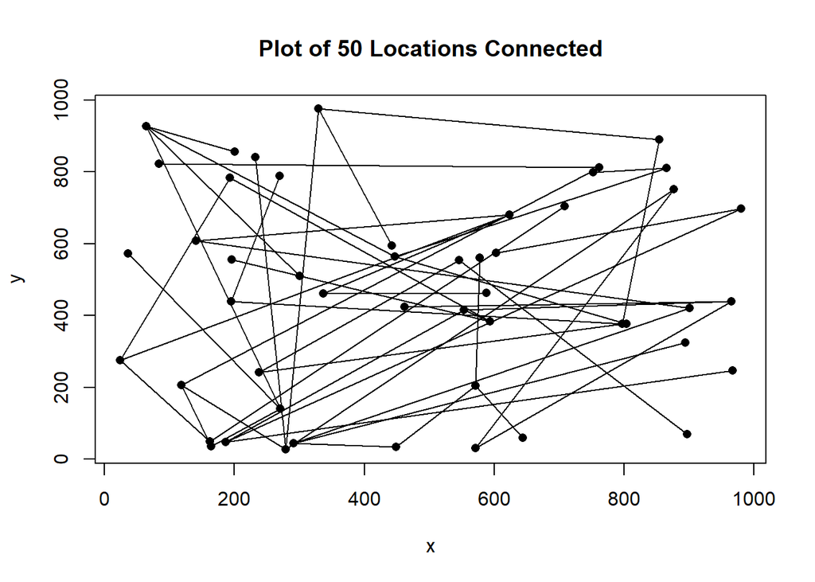

```r
plot.mst <- function(arcList) {
  for (i in 1:n) {
    segments(x[ds.mst$tree.arcs[,1]], y[ds.mst$tree.arcs[,1]], x[ds.mst$tree.arcs[,2]], y[ds.mst$tree.arcs[,2]])
   #segments(x[arcList[i,1]], y[arcList[i,2]], x[arcList[i,1], y[arcList[i,2]])   #removed i's
  }
}
plot(x,y, pch = 16, main = "Plot of 50 Locations Connected")
plot.mst(ds.mst$tree.arcs)
```

# 4 Hostile Agents

#### Parts 1 & 2: Specify problem as a graph optimization problem as well as structuring inputs to the problem.

- This problem can be viewed as: For each agent, originating from the Source, s to Sink, t, a message can be sent or received for each intermediate step in the process. For example, Agent A can reach out to multiple agents, as well as receive code from other agents from the same node so this graph may be acyclic.

#### Parts 3 & 4: Which Algorithm do you use to solve it and what is the computational efficiency?

- This can be views as a Dijkstra-Prim Minimum Spanning Tree algorithm that has computational efficients of O(E lg V), which makes it the N lg N algorithm class. This is as efficient as sorting.

# 5 Project Scheduling

```r
# Associate completion time with each node:

s.label_names <- c('a', 'b', 'c', 'd', 'e', 'f', 'g', 'h', 'i', 'j' , 'z')
s.labels <-      c( 1 ,  2 ,  3 ,  4 ,  5 ,  6 ,  7 ,  8 ,  9 ,  10 ,  11)
s.nodes_EF <-    c( 90 ,  15,   5,  20,  21,  25,  14,  28,  30,  45, 21, 28)

########### 5.4: Earliest Start Times
# Each arc has a weight, and a start and end node
ab <- c(s.labels[1], s.labels[2], -90)  #arc ab is 90
bc <- c(s.labels[2], s.labels[3], -15)  #arc bc is 15
cg <- c(s.labels[3], s.labels[7], -5)  #arc cg is 5
# gd <- c(s.labels[7], s.labels[4], -14)  #arc gd is 14
dj <- c(s.labels[4], s.labels[10], -20)  #arc dj1 is 20
dh <- c(s.labels[4], s.labels[8], -20)  #arc dh is 20
de <- c(s.labels[4], s.labels[5], -20)  #arc de is 20
af <- c(s.labels[1], s.labels[6], -90)  #arc af is 90
fg <- c(s.labels[6], s.labels[7], -25)  #arc fg is 25
gd <- c(s.labels[7], s.labels[4], -14)  #arg dg is 14
ai <- c(s.labels[1], s.labels[9], -90)  #arc ai is 90
ij <- c(s.labels[9], s.labels[10], -30)  #arc ij is 30
jz <- c(s.labels[10], s.labels[11], -45)  #arc jz is 0
ez <- c(s.labels[5], s.labels[11], -21)  #arc jz is 0
hz <- c(s.labels[8], s.labels[11], -28)  #arc jz is 0

ds3 <- rbind(ab, bc, cg, gd, dj, dh, de, af, fg, gd, ai, ij, jz, ez, hz)
nodes <- 1:11
arcs <- ds3
ES <- getShortestPathTree(nodes = nodes, arcs = arcs, "Bellman-Ford", source.node = 1)
```

```
##
##  Shortest path tree
##  Algorithm: Bellman-Ford
##  Stages:  10 | Time:  0
##  ------------------------------
##       head     tail    weight
##          1        2       -90
##          1        6       -90
##          1        9       -90
##          2        3       -15
##          4        5       -20
##          4        8       -20
##          4       10       -20
##          6        7       -25
##          7        4       -14
##         10       11       -45
##  ------------------------------
##                    Total = -429
##
##  Distances from source:
##  ------------------------------
##     source     node  distance
##          1        2       -90
##          1        3      -105
##          1        4      -129
##          1        5      -149
##          1        6       -90
##          1        7      -115
##          1        8      -149
##          1        9       -90
##          1       10      -149
##          1       11      -194
##  ------------------------------
```

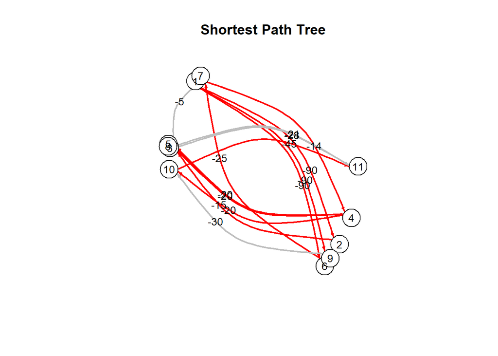

```r
ES <- ES$distances*-1
print("The Earliest Start (ES) times for each node are below:")
```

```
## [1] "The Earliest Start (ES) times for each node are below:"
```

```r
rbind(ES, s.label_names)                  #rbind(ES[1:10], s.label_names[1:10])
```

```
##               [,1] [,2] [,3]  [,4]  [,5]  [,6] [,7]  [,8]  [,9] [,10]
## ES            "0"  "90" "105" "129" "149" "90" "115" "149" "90" "149"
## s.label_names "a"  "b"  "c"   "d"   "e"   "f"  "g"   "h"   "i"  "j"
##               [,11]
## ES            "194"
## s.label_names "z"
```

```r
############ 5.5 Earliest Overall Project Completion
max(ES)   # takes from node J --> END
```

```
## [1] 194
```

```r
st <- as.Date("2019-11-01") + max(ES)
print(paste("The earliest finish for the project is" , st))
```

```
## [1] "The earliest finish for the project is 2020-05-13"
```

```r
############ 5.6 Earliest Finish Times
duration <- c( 90 ,  15,   5,  20,  21,  25,  14,  28,  30,  45, 21)   #28
print("The Earliest Finish (EF) times for each node are below:")
```

```
## [1] "The Earliest Finish (EF) times for each node are below:"
```

```r
EF <- ES + duration
(rbind(EF[1:10], s.label_names[1:10]))
```

```
##      [,1] [,2]  [,3]  [,4]  [,5]  [,6]  [,7]  [,8]  [,9]  [,10]
## [1,] "90" "105" "110" "149" "170" "115" "129" "177" "120" "194"
## [2,] "a"  "b"   "c"   "d"   "e"   "f"   "g"   "h"   "i"   "j"
```

```r
############5.7 Latest Finish Times

              #    a,   b,   c,   d,   e,   f,   g,   h,   i,  j, z
s.labelsLF <- c(1   ,   2,   3,   4,   5,   6,   7,   8,   9, 10, 11)
s.nodes_LF <- c(90 ,  15,   5,  20,  21,  25,  14,  28,  30,  45, 0)

# work backwards for Latest Finish Time
zh <- c(s.labelsLF[11], s.labelsLF[8], 0)  #arc zh is 0
ze <- c(s.labelsLF[11], s.labelsLF[5], 0)  #arc ze is 0
zj <- c(s.labelsLF[11], s.labelsLF[10], 0)  #arc zj is 0
hd <- c(s.labelsLF[8], s.labelsLF[4], -28)  #arc hd is 28
ed <- c(s.labelsLF[5], s.labelsLF[4], -21)  #arc ed is 21
jd <- c(s.labelsLF[10], s.labelsLF[4], -45)  #arc jd is 45
ji <- c(s.labelsLF[10], s.labelsLF[9], -45)  #arc ji is 45
dg <- c(s.labelsLF[4], s.labelsLF[7], -20)  #arc dg is 20
gc <- c(s.labelsLF[7], s.labelsLF[3], -14)  #arc gc is 14
gf <- c(s.labelsLF[7], s.labelsLF[6], -14)  #arc gf is 14
fa <- c(s.labelsLF[6], s.labelsLF[1], -25)  #arc fa is 25
cb <- c(s.labelsLF[3], s.labelsLF[2], -5 )  #arc cb is 5
ba <- c(s.labelsLF[2], s.labelsLF[1], -15 )  #arc ba is 15
ia <- c(s.labelsLF[9], s.labelsLF[1], -30 )  #arc ia is 30

ds4 <-rbind(ia, ba, cb, fa, gf, gc, dg, ji, jd, ed, hd, zj, ze, zh)                                    # rbind(zh,ze,zj,hd,ed,jd,ji,dg,gc,gf,fa,cb,ba,ia)
nodes <- 1:11
arcs <- ds4
LF <- getShortestPathTree(nodes = nodes, arcs = arcs, "Bellman-Ford", source.node = 11)
```

```
##
##  Shortest path tree
##  Algorithm: Bellman-Ford
##  Stages:  10 | Time:  0
##  ------------------------------
##       head     tail    weight
##          3        2        -5
##          4        7       -20
##          6        1       -25
##          7        3       -14
##          7        6       -14
##         10        4       -45
##         10        9       -45
##         11        5         0
##         11        8         0
##         11       10         0
##  ------------------------------
##                    Total = -168
##
##  Distances from source:
##  ------------------------------
##     source     node  distance
##         11        1      -104
##         11        2       -84
##         11        3       -79
##         11        4       -45
##         11        5         0
##         11        6       -79
##         11        7       -65
##         11        8         0
##         11        9       -45
##         11       10         0
##  ------------------------------
```

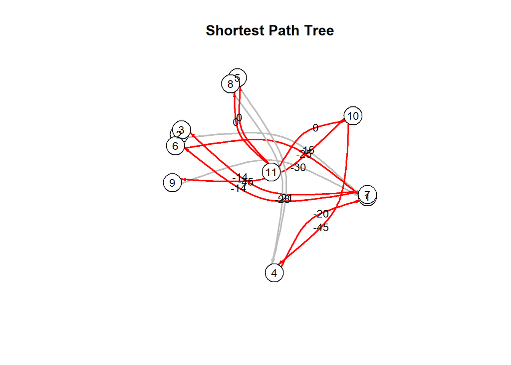

```r
LF <- LF$distances*-1
print("The Latest Finish times (LF) for each node is below")
```

```
## [1] "The Latest Finish times (LF) for each node is below"
```

```r
(rbind(LF, s.label_names))   #[1:10][1:10]
```

```
##               [,1]  [,2] [,3] [,4] [,5] [,6] [,7] [,8] [,9] [,10] [,11]
## LF            "104" "84" "79" "45" "0"  "79" "65" "0"  "45" "0"   "0"
## s.label_names "a"   "b"  "c"  "d"  "e"  "f"  "g"  "h"  "i"  "j"   "z"
```

```r
############ 5.8 Latest Start Times

durationbw <- c(90 ,  15,   5,  20,  21,  25,  14,  28,  30,  45, 0)
#  durationbw<- c(0 ,  45, 30,  28,  14,  25,  21,  20, 5,  15, 90)
  #c( 0, 0, 0, 28 ,21, 45, 45,  20,  14,  14,  25, 5, 15, 30)
print("The Latest Start times (LS) for each node are below:")
```

```
## [1] "The Latest Start times (LS) for each node are below:"
```

```r
(LS = LF - durationbw)
```

```
##  [1]  14  69  74  25 -21  54  51 -28  15 -45   0
```

```r
############ 5.9 Slack
print("The Slack for each node is below")
```

```
## [1] "The Slack for each node is below"
```

```r
slack <- LS - ES


slack
```

```
##  [1]   14  -21  -31 -104 -170  -36  -64 -177  -75 -194 -194
```

# Summary of Question 5:

### While the output doesnt clearly indicate the positive slack and critical paths, I have summarized them below:

#### The slack is the difference from the Latest Start (LS) minus the Earliest Start.

- Task A
- Task F
- Task G
- Task D
- Task J

#### The critical path flow is:

## A –> F –> G –> D –> J

##### Another visual representation of the scheduling problem, with the Critical Path highlighted can be found below.

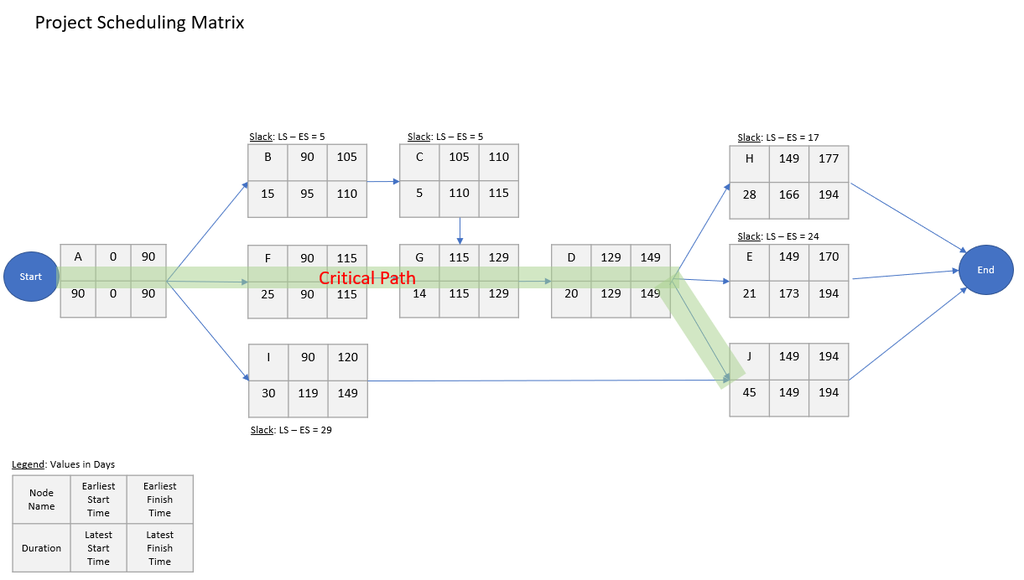